# Множественная регрессия: построение и интепретация моделей

Заходякин Г.В., postlogist@gmail.com

02.03.2018

# Модель множественной регрессии

Модель **множественной линейной регрессии** (*multiple linear regression*) позволяет предсказывать непрерывную выходную переменную на основе **нескольких** объясняющих переменных. При этом объясняющие переменные могут быть непрерывными или бинарными (0-1).

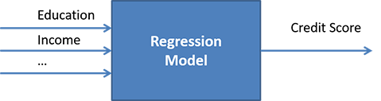

Множественная регрессия - предсказание непрерывной выходной переменной на основе нескольких объясняющих переменных

Модель множественной регрессии включает несколько объясняющих переменных, для каждой из которой используется отдельный коэффициент:

$$y = \beta_0 + \beta_1 x_1 + \beta_2 x_2 + \ldots + \beta_k x_k + \varepsilon$$

В этом уравнении $y$ - выходная переменная, а $x_1, x_2, \ldots, x_k$ - объясняющие переменные.

Угловые коэффициенты (*slope coefficients*) $\beta_1, \beta_2, \ldots, \beta_k$ измеряют влияние соответствующей объясняющей переменной с учетом влияния всех остальных объясняющих переменных (т.е. при прочих равных). Например, коэффициент $\beta_1$ показывает ожидаемое изменение $y$ при единичном увеличении $x_1$, в то время как остальные предикторы - $x_2, x_3, \ldots, x_k$ - будут зафиксированы.

Таким образом, коэффициент для переменной в уравнении множественной регрессии отражает **предельный эффект** (*marginal effect*) этой переменной при зафиксированных значениях остальных переменных:

$$\beta_j = \frac {\partial{y}} {\partial{x_j}}$$

**Свободный член** (*intercept*) $\beta_0$ отражает значение выходной переменной $y$ в точке, где все предикторы равны нулю.

Как и случае с простой линейной регрессией, для остатка модели $\varepsilon$ предполагаются следующие свойства:

1. **Среднее значение остатка - нулевое** (нет систематической ошибки)

$$E(\varepsilon)=0$$

2. **Остатки модели некоррелированы между собой**:

$$\rho(\varepsilon_i, \varepsilon_k) = 0, \forall i \ne k$$

Если данное предположение нарушается, то модель будет неэффективной, т.е. можно построить более точную модель на тех же данных. Причина в том, что корреляция остатков между собой - это полезная информация, которая может быть учтена в модели для снижения ошибки.

3. **Остатки модели некоррелированы с объясняющей переменной**:

$$\rho(\varepsilon, x_j) = 0, \forall x_j$$

Это предположение распространяется и на другие переменные в наборе данных. Если есть зависимость остатков от другой переменной, то можно улучшить точность модели, включив в нее эту переменную.

4. **Дисперсия (и стандартное отклонение) остатков постоянна**, т.е. не зависит от $x$:

$$\sigma_\varepsilon = const, \forall x$$

Данное допущение называется **гомоскедастичностью** (homoscedasticity).

5. **Распределение остатков модели - нормальное**:
   $$\varepsilon \sim N(0, \sigma).$$

Оценка коэффициентов уравнения множественной регрессии:

$$y = b_0 + b_1 x_1 + b_2 x_2 + \ldots + b_k x_k + e$$

- выполняется методом наименьших квадратов, т.е. по критерию минимизации суммы квадратов остатков:

$$\sum_{i=1}^N e_i^2 = \sum_{i=1}^N(y_i - b_0 - b_1 x_{i,1} - \ldots - b_k x_{i,k})^2.$$

В методе МНК используется формула в явном виде для вычисления коэффициентов. Поскольку эта формула предполагает громоздкие операции с матрицами, коэффициенты на практике всегда вычисляются с помощью компьютерных программ.

Для оценки модели (*model fitting*) в R используется та же функция `lm()`, что и для простой линейной регрессии.

# Пример разработки моделей множественной регрессии

В этом примере мы исследуем влияние различных факторов на расход топлива для автомобилей. Данные находятся в файле `datasets/cars.csv`.

## Подготовка

Загрузка пакетов

```r
library(readr) # считывание данных из текстовых файлов
library(tidyverse) # манипулирование данными
library(ggplot2) # визуализация
library(ggfortify) # визуализация диагностических графиков
library(modelr) # вспомогательные функции для работы с моделями
library(broom) # преобразование результатов моделирования в табличный вид
library(GGally) # построение матрицы диаграмм рассеяния
library(car) # функции для степенных преобразований
library(forcats) # работа с факторами
```

Загрузка данных

```r
cars <- read_csv2("datasets/cars.csv", skip = 25) #в файле используются "русские" разделители, больше подходит read_csv2()
glimpse(cars)
```

```
## Observations: 157
## Variables: 14
## $ manufact       <chr> "Acura", "Acura", "Acura", "Acura", "Audi", "Audi", "Audi", "BMW", "BMW"...
## $ model          <chr> "Integra", "TL", "CL", "RL", "A4", "A6", "A8", "323i", "328i", "528i", "...
## $ manufact_model <chr> "Acura Integra", "Acura TL", "Acura CL", "Acura RL", "Audi A4", "Audi A6...
## $ country        <chr> "Japan", "Japan", "Japan", "Japan", "Europe", "Europe", "Europe", "Europ...
## $ type           <chr> "Automobile", "Automobile", "Automobile", "Automobile", "Automobile", "A...
## $ price          <dbl> 21.50, 28.40, NA, 42.00, 23.99, 33.95, 62.00, 26.99, 33.40, 38.90, 21.98...
## $ engine_s       <dbl> 1.8, 3.2, 3.2, 3.5, 1.8, 2.8, 4.2, 2.5, 2.8, 2.8, 3.1, 3.8, 3.8, 3.8, 4....
## $ horsepow       <int> 140, 225, 225, 210, 150, 200, 310, 170, 193, 193, 175, 240, 205, 205, 27...
## $ wheelbas       <dbl> 101.2, 108.1, 106.9, 114.6, 102.6, 108.7, 113.0, 107.3, 107.3, 111.4, 10...
## $ width          <dbl> 67.3, 70.3, 70.6, 71.4, 68.2, 76.1, 74.0, 68.4, 68.5, 70.9, 72.7, 72.7, ...
## $ length         <dbl> 172, 193, 192, 197, 178, 192, 198, 176, 176, 188, 195, 196, 207, 200, 20...
## $ curb_wgt       <dbl> 2.64, 3.52, 3.47, 3.85, 3.00, 3.56, 3.90, 3.18, 3.20, 3.47, 3.37, 3.54, ...
## $ fuel_cap       <dbl> 13.2, 17.2, 17.2, 18.0, 16.4, 18.5, 23.7, 16.6, 16.6, 18.5, 17.5, 17.5, ...
## $ mpg            <dbl> 28.0, 25.0, 26.0, 22.0, 27.0, 22.0, 21.0, 26.1, 24.0, 24.8, 25.0, 23.0, ...
```

## Разведочный анализ

### Пропущенные наблюдения

```r
cars %>%
  gather(key = 'Переменная', value = 'Значение') %>%
  group_by(`Переменная`) %>%
  summarise(`Пропуски` = sum(is.na(`Значение`))) %>%
  arrange(-`Пропуски`)
```

```
## # A tibble: 14 x 2
##        Переменная Пропуски
##             <chr>    <int>
##  1            mpg        3
##  2       curb_wgt        2
##  3          price        2
##  4       engine_s        1
##  5       fuel_cap        1
##  6       horsepow        1
##  7         length        1
##  8       wheelbas        1
##  9          width        1
## 10        country        0
## 11       manufact        0
## 12 manufact_model        0
## 13          model        0
## 14           type        0
```

Количество строк с пропусками можно определить с помощью функции `complete.cases()`, которая выдает для каждой строки набора данных `TRUE` или `FALSE`, в зависимости от того, известны ли все значения переменных для примера в этой строке.

```r
cars %>%
  filter(!complete.cases(.)) # . обозначает место, в которое надо подставить результат предыдущей операции
```

```
## # A tibble: 5 x 14
##     manufact          model          manufact_model country       type price engine_s horsepow
##        <chr>          <chr>                   <chr>   <chr>      <chr> <dbl>    <dbl>    <int>
## 1      Acura             CL                Acura CL   Japan Automobile    NA      3.2      225
## 2   Cadillac        Seville        Cadillac Seville     USA Automobile  44.5      4.6      275
## 3      Dodge       Intrepid          Dodge Intrepid     USA Automobile  22.5      2.7      202
## 4 Oldsmobile       Intrigue     Oldsmobile Intrigue     USA Automobile  24.1      3.5      215
## 5   Chrysler Town & Country Chrysler Town & Country     USA      Truck    NA       NA       NA
## # ... with 6 more variables: wheelbas <dbl>, width <dbl>, length <dbl>, curb_wgt <dbl>,
## #   fuel_cap <dbl>, mpg <dbl>
```

Всего в наборе данных содержится 13 пропущенных значений, строк с хотя бы одним пропуском - 5. Это небольшой процент от общего числа наблюдений (157), поэтому для дальнейшего анализа исключим наблюдения с пропущенными значениями.

```r
cars2 <- na.omit(cars)

# Осталось наблюдений:
cat("Осталось", nrow(cars2), "наблюдений из", nrow(cars))
```

```
## Осталось 152 наблюдений из 157
```

### Связи между переменными

Первые 5 столбцов в наборе данных содержат текстовые переменные, которые нельзя использовать для корреляционного анализа. Отберем только числовые столбцы и исследуем корреляции между ними.

```r
cars_num <- cars2 %>% select_if(is.numeric)

# Коэффициенты корреляции и из значимость
Hmisc::rcorr(as.matrix(cars_num))
```

```
##          price engine_s horsepow wheelbas width length curb_wgt fuel_cap   mpg
## price     1.00     0.62     0.84     0.11  0.33   0.15     0.53     0.42 -0.49
## engine_s  0.62     1.00     0.84     0.47  0.69   0.54     0.76     0.67 -0.74
## horsepow  0.84     0.84     1.00     0.28  0.53   0.38     0.61     0.51 -0.62
## wheelbas  0.11     0.47     0.28     1.00  0.68   0.84     0.65     0.66 -0.50
## width     0.33     0.69     0.53     0.68  1.00   0.71     0.72     0.66 -0.60
## length    0.15     0.54     0.38     0.84  0.71   1.00     0.63     0.57 -0.45
## curb_wgt  0.53     0.76     0.61     0.65  0.72   0.63     1.00     0.86 -0.82
## fuel_cap  0.42     0.67     0.51     0.66  0.66   0.57     0.86     1.00 -0.80
## mpg      -0.49    -0.74    -0.62    -0.50 -0.60  -0.45    -0.82    -0.80  1.00
##
## n= 152
##
##
## P
##          price  engine_s horsepow wheelbas width  length curb_wgt fuel_cap mpg
## price           0.0000   0.0000   0.1834   0.0000 0.0567 0.0000   0.0000   0.0000
## engine_s 0.0000          0.0000   0.0000   0.0000 0.0000 0.0000   0.0000   0.0000
## horsepow 0.0000 0.0000            0.0004   0.0000 0.0000 0.0000   0.0000   0.0000
## wheelbas 0.1834 0.0000   0.0004            0.0000 0.0000 0.0000   0.0000   0.0000
## width    0.0000 0.0000   0.0000   0.0000          0.0000 0.0000   0.0000   0.0000
## length   0.0567 0.0000   0.0000   0.0000   0.0000        0.0000   0.0000   0.0000
## curb_wgt 0.0000 0.0000   0.0000   0.0000   0.0000 0.0000          0.0000   0.0000
## fuel_cap 0.0000 0.0000   0.0000   0.0000   0.0000 0.0000 0.0000            0.0000
## mpg      0.0000 0.0000   0.0000   0.0000   0.0000 0.0000 0.0000   0.0000
```

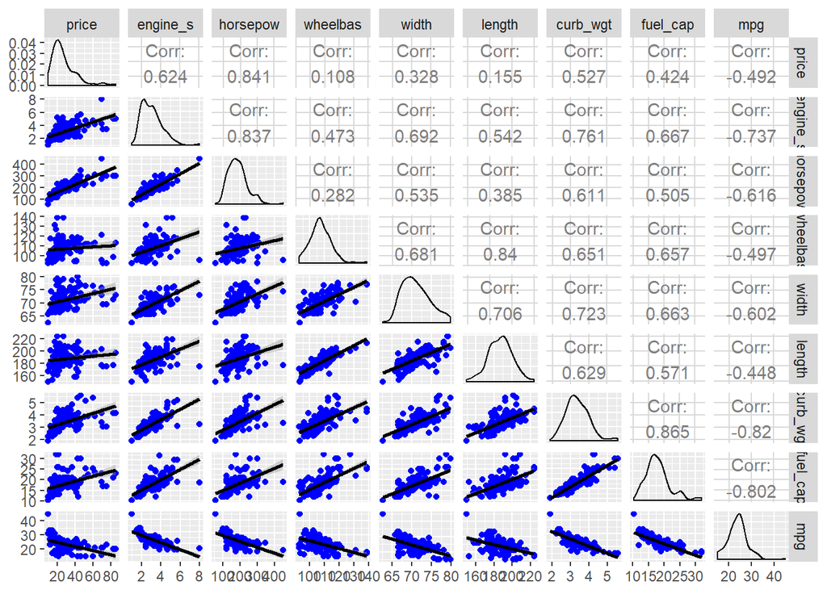

```r
# Матрица диаграмм рассеяния
ggpairs(cars_num,
        lower = list(continuous = wrap("smooth_lm", color = 'blue')))
```

На диаграммах рассеяния видна зависимость между всеми переменными и `mpg`. Коэффициенты корреляции отрицательны и статистически значимы.

Для большого количества переменных матрица диаграмм рассеяния получается слишком громоздкой. Лучше исследовать связь каждой переменной с целевой в отдельности. Для этого придется преобразовать данные в “длинный” формат.

```r
cars_tall <- cars2 %>%
  gather(key = 'Показатель', value = 'Значение', price:fuel_cap) # текстовые переменные и mpg надо оставить без изменений
```

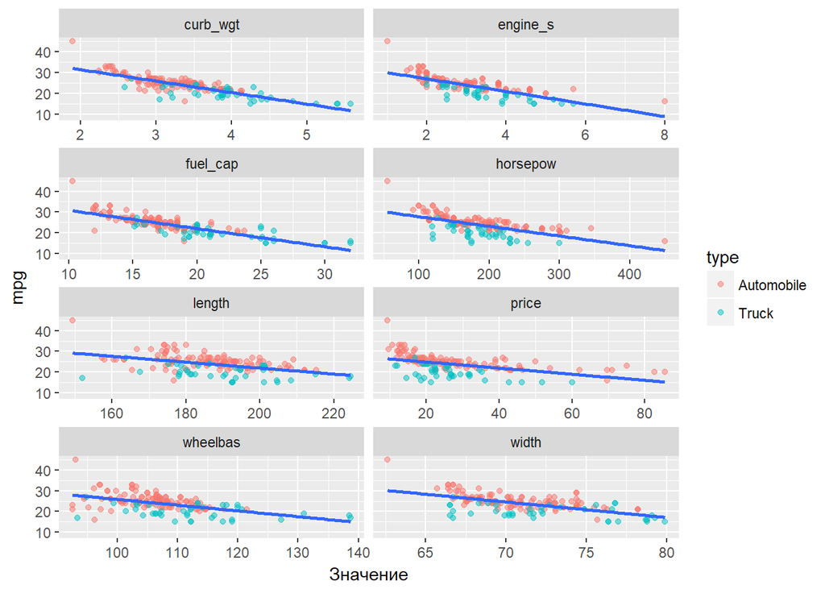

```r
ggplot(data = cars_tall,
       mapping = aes(x = `Значение`, y = mpg)) +
  geom_point(aes(colour = type), alpha = 0.5) +
  stat_smooth(method = lm, se = F) +
  facet_wrap(~ `Показатель`, scale = 'free_x', ncol = 2)
```

На этой диаграмме зависимости можно рассмотреть более подробно. Видно, что некоторые связи - нелинейные, есть выбросы, непостоянство дисперсии. Также заметно расслоение облака точек по типу машины - грузовик или легковой автомобиль. Эти особенности необходимо учесть при построении моделей.

## Моделирование

### Линейная регрессия

На основе результатов корреляционного анализа можно предположить, что наилучшим предиктором для топливной эффективности будет вес машины `curb_wgt`, т.к. коэффициент корреляции для этой переменной наибольший по модулю:

```r
cars_tall %>%
  group_by(`Показатель`) %>%
  summarise(r = cor(mpg, `Значение`)) %>%
  arrange(desc(abs(r)))
```

```
## # A tibble: 8 x 2
##   Показатель      r
##        <chr>  <dbl>
## 1   curb_wgt -0.820
## 2   fuel_cap -0.802
## 3   engine_s -0.737
## 4   horsepow -0.616
## 5      width -0.602
## 6   wheelbas -0.497
## 7      price -0.492
## 8     length -0.448
```

Построим модель простой линейной регрессии по переменной `curb_wgt`:

```r
m_wgt <- lm(mpg ~ curb_wgt, data = cars2)
summary(m_wgt)
```

```
##
## Call:
## lm(formula = mpg ~ curb_wgt, data = cars2)
##
## Residuals:
##    Min     1Q Median     3Q    Max
## -8.677 -1.057  0.325  1.316 12.948
##
## Coefficients:
##             Estimate Std. Error t value Pr(>|t|)
## (Intercept)   42.556      1.086    39.2   <2e-16 ***
## curb_wgt      -5.543      0.316   -17.5   <2e-16 ***
## ---
## Signif. codes:  0 '***' 0.001 '**' 0.01 '*' 0.05 '.' 0.1 ' ' 1
##
## Residual standard error: 2.47 on 150 degrees of freedom
## Multiple R-squared:  0.672,  Adjusted R-squared:  0.67
## F-statistic:  307 on 1 and 150 DF,  p-value: <2e-16
```

В табличном виде коэффициенты модели можно получить с помощью функции `broom::tidy()`.

```r
tidy(m_wgt) %>% select(term:std.error) # эта же информация есть и в summary()
```

```
##          term estimate std.error
## 1 (Intercept)    42.56     1.086
## 2    curb_wgt    -5.54     0.316
```

Получена модель:

$$\widehat{mpg} = 42.556 - 5.543 \cdot curb\_wgt$$

На каждую тысячу фунтов пробег автомашины на 1 галлоне топлива сокращается на 5.5 миль.

По F-критерию модель значима. Также t-критерии показывают значимость коэффициентов модели.

Визуализация модели:

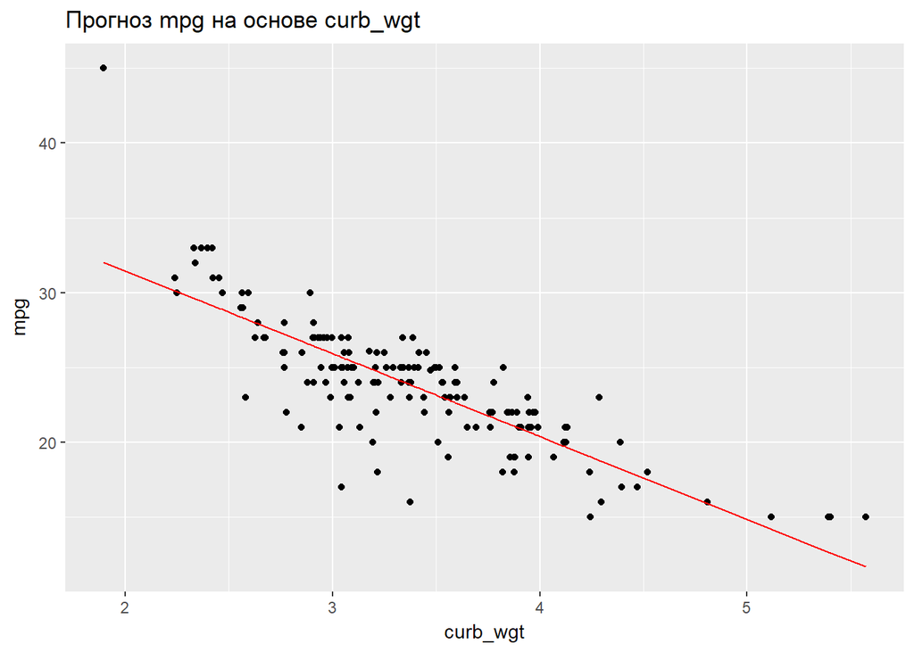

```r
ggplot(add_predictions(cars2, m_wgt, var = 'fit')) +
  geom_point(aes(curb_wgt, mpg)) +
  geom_line(aes(curb_wgt, fit), colour = 'red') +
  labs(title = 'Прогноз mpg на основе curb_wgt')
```

Рассмотрим подробнее сводку по модели:

```r
glance(m_wgt) %>% select(r.squared, sigma) # эта же информация есть и в summary()
```

```
##   r.squared sigma
## 1     0.672  2.47
```

Модель объяснила 67.2% дисперсии исходных данных, ее стандартная ошибка равна 2.47 мили на галлон топлива.

### Множественная регрессия с двумя предикторами

Точность модели можно улучшить, если добавить в модель другие предикторы. Попробуем найти наилучшего кандидата на роль второго предиктора, посчитав корреляцию остальных переменных с остатками первой модели.

```r
cars2 %>%
  add_residuals(m_wgt, var = "residual") %>% #добавили остатки
  select_if(is.numeric) %>% # убрали текстовые столбцы
  select(-curb_wgt, -mpg) %>% #убрали уже учтенные в модели переменные
  gather('var', 'value', price:fuel_cap) %>% #длинный формат данных
  group_by(var) %>% # сгруппировали по названию переменной
  summarise(r = cor(value, residual)) %>% # посчитали коэффициент корреляции для каждой группы
  arrange(desc(abs(r)))
```

```
## # A tibble: 7 x 2
##        var       r
##      <chr>   <dbl>
## 1 horsepow -0.2020
## 2 engine_s -0.1982
## 3 fuel_cap -0.1622
## 4   length  0.1191
## 5    price -0.1039
## 6 wheelbas  0.0638
## 7    width -0.0166
```

Наибольший по модулю коэффициент корреляции с остатками первой модели - у переменной `horsepow` - мощность двигателя.

Во второй модели рассмотрим одновременное влияние веса машины и ее мощности.

```r
m_wgtpow <- lm(mpg ~ curb_wgt + horsepow, data = cars2)
summary(m_wgtpow)
```

```
##
## Call:
## lm(formula = mpg ~ curb_wgt + horsepow, data = cars2)
##
## Residuals:
##    Min     1Q Median     3Q    Max
## -9.331 -1.166  0.268  1.416 12.262
##
## Coefficients:
##             Estimate Std. Error t value Pr(>|t|)
## (Intercept) 42.56737    1.05401   40.39   <2e-16 ***
## curb_wgt    -4.78164    0.38741  -12.34   <2e-16 ***
## horsepow    -0.01397    0.00434   -3.22   0.0016 **
## ---
## Signif. codes:  0 '***' 0.001 '**' 0.01 '*' 0.05 '.' 0.1 ' ' 1
##
## Residual standard error: 2.4 on 149 degrees of freedom
## Multiple R-squared:  0.693,  Adjusted R-squared:  0.689
## F-statistic:  168 on 2 and 149 DF,  p-value: <2e-16
```

Модель в целом значима. Все угловые коэффициенты и свободный член также значимы.

Получена модель:

$$\widehat{mpg} = 42.57 - 4.78 \cdot curb\_wgt - 0.014 \cdot horsepow$$

Коэффициенты модели можно интерпретировать так:

- среди автомобилей одинаковой мощности, каждая дополнительная тысяча фунтов веса уменьшает пробег на 4.78 мили на галлон;
- среди автомобилей одинакового веса, каждая лошадиная сила снижает пробег на 0.014 мили на галлон.

Коэффициент детерминации $R^2$ немного улучшился: 69.3% вместо 67.2%

Сделаем по второй модели интервальный прогноз пробега на 1 галлоне для машины весом 4 тысячи фунтов и мощностью 200 лошадиных сил. Для этого нужно создать новый набор данных, содержащий эти две переменные:

```r
newcar <- tibble(curb_wgt = 4, horsepow = 200)
predict(m_wgtpow, newcar, interval = 'prediction', level = 0.9 )
```

```
##    fit  lwr  upr
## 1 20.6 16.6 24.6
```

Согласно прогнозу, можно ожидать, что пробег такой машины с 90% надежностью составит от ~17 до ~25 миль на одном галлоне.

Поскольку в уравнение регрессии входит 3 переменных, модель невозможно визуализировать на плоской диаграмме. Мы могли бы зафиксировать один из предикторов и построить диаграмму с учетом второго, однако этот подход неудобно использовать для моделей с большим числом предикторов. Поэтому просто сравним прогнозы модели с фактом.

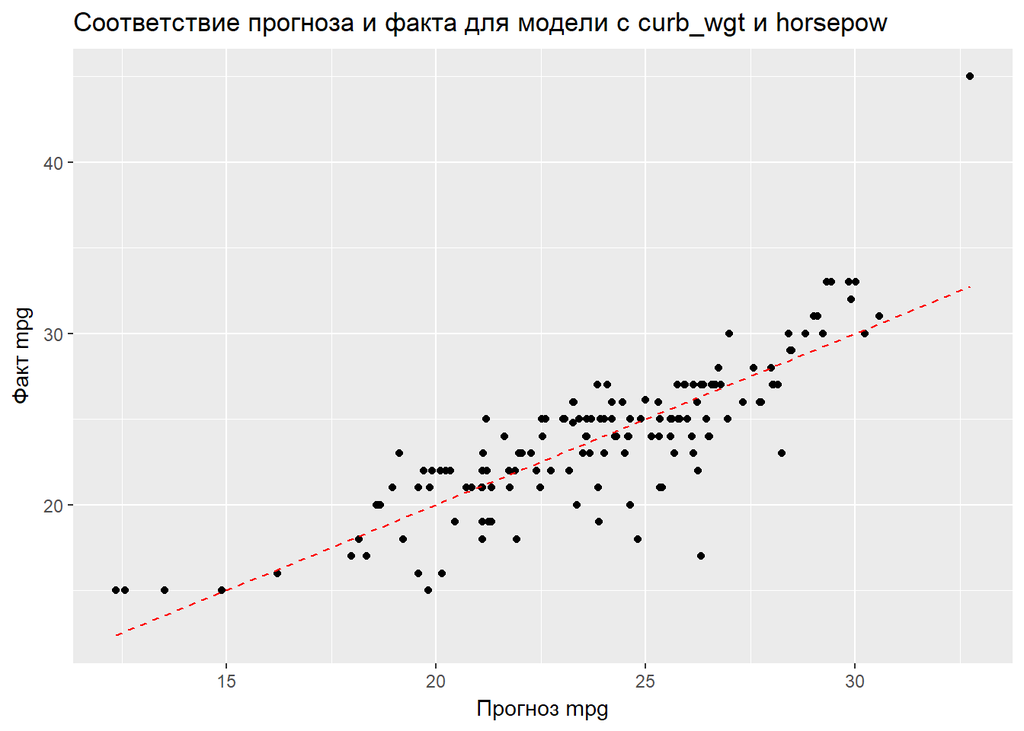

```r
ggplot(add_predictions(cars2, m_wgtpow, var = 'fit'),
       aes(fit, mpg)) +
  geom_point() +
  geom_line(aes(fit, fit), color = 'red', linetype = 'dashed') +
  labs(title = 'Соответствие прогноза и факта для модели с curb_wgt и horsepow',
       x = 'Прогноз mpg',
       y = 'Факт mpg')
```

При идеальном соответствии прогноза и факта была бы получена прямая линия. В реальности же наблюдается отклонение фактических значений от предсказанных.

Исследуем остатки модели.

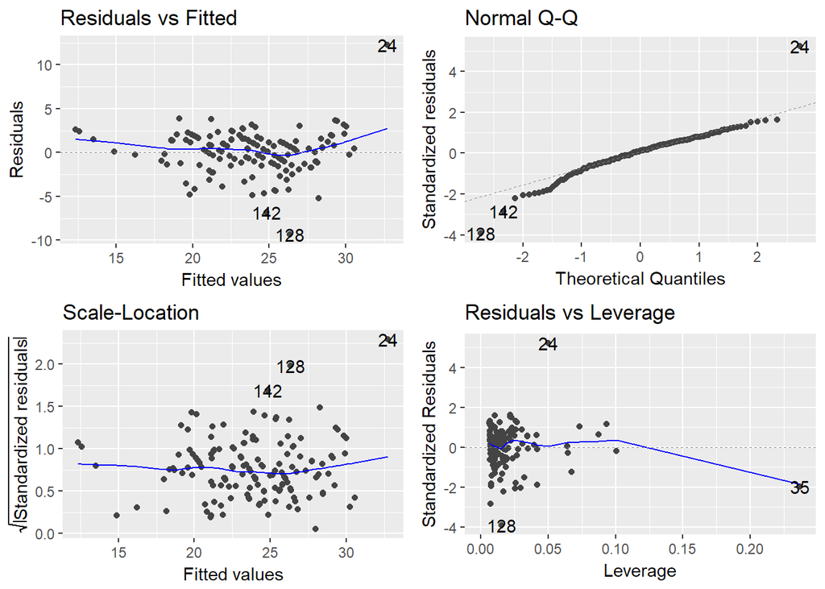

```r
autoplot(m_wgtpow)
```

Наблюдается слабо выраженная нелинейность. Также имеются отклонения от нормальности в хвостах распределения остатков, есть подозрение на гетероскедастичность и наличие влиятельных наблюдений.

```r
m_wgtpow_fit <- m_wgtpow %>%
  fortify() %>% # сохранили остатки, предсказания и показатели влиятельности в набор
  merge(., cars2) # добавили исходные данные (merge удаляет дублирующиеся при слиянии столбцы)

head(m_wgtpow_fit)
```

```
##   mpg curb_wgt horsepow   .hat .sigma  .cooksd .fitted .resid .stdresid manufact        model
## 1  15     4.25      175 0.0296   2.37 4.23e-02    19.8 -4.824   -2.0404    Dodge    Ram Wagon
## 2  15     5.12      230 0.0640   2.41 4.61e-05    14.9  0.104    0.0449   Toyota Land Cruiser
## 3  15     5.39      300 0.0731   2.40 2.87e-02    12.6  2.412    1.0437  Lincoln    Navigator
## 4  15     5.40      230 0.0875   2.40 1.32e-02    13.5  1.472    0.6420    Lexus        LX470
## 5  15     5.57      255 0.0934   2.40 4.58e-02    12.4  2.639    1.1547 Cadillac     Escalade
## 6  16     3.38      450 0.2367   2.38 4.03e-01    20.1 -4.142   -1.9751    Dodge        Viper
##        manufact_model country       type price engine_s wheelbas width length fuel_cap
## 1     Dodge Ram Wagon     USA      Truck  21.3      3.9    109.6  78.8    193     32.0
## 2 Toyota Land Cruiser   Japan      Truck  51.7      4.7    112.2  76.4    192     25.4
## 3   Lincoln Navigator     USA      Truck  42.7      5.4    119.0  79.9    205     30.0
## 4         Lexus LX470   Japan      Truck  60.1      4.7    112.2  76.4    192     25.4
## 5   Cadillac Escalade     USA      Truck  46.2      5.7    117.5  77.0    201     30.0
## 6         Dodge Viper     USA Automobile  69.7      8.0     96.2  75.7    177     19.0
```

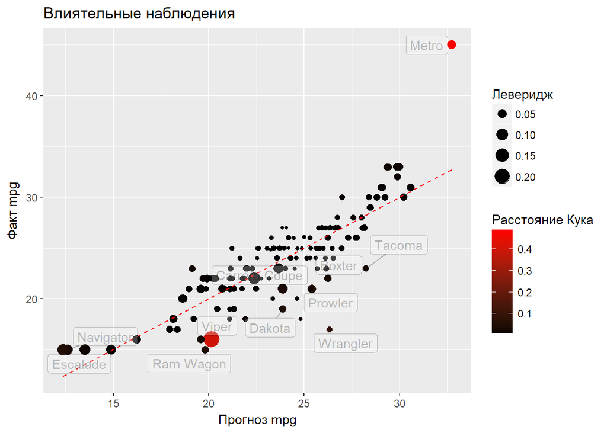

```r
ggplot(m_wgtpow_fit, aes(.fitted, mpg)) +
  geom_point(aes(size = .hat, colour = .cooksd)) +
  geom_line(aes(.fitted, .fitted),
            colour = "red", linetype = "dashed") +
  scale_colour_gradient(low = "black", high = "red") +
  ggrepel::geom_label_repel(
    data = filter(m_wgtpow_fit, .cooksd > 4/nrow(cars2)),
    mapping = aes(label = model), alpha = 0.25) +
  labs(title = "Влиятельные наблюдения",
       x = "Прогноз mpg", y = "Факт mpg",
       size = "Леверидж",  colour = "Расстояние Кука")
```

Наиболее влиятельным наблюдением является модель Viper, у которой наибольшее значение левериджа, т.е. удаленности от прочих наблюдений в пространстве предикторов (мощность, вес) и большое расстояние Кука (коэффициенты модели сильно меняются, если удалить это наблюдение). Также влиятельным наблюдением является модель Metro, у которой большой остаток и расстояние Кука.

### Регрессия с категориальными предикторами

Рассмотрим влияние мощности двигателя на пробег. Поскольку в данных имеются два типа машин - автомобили и грузовики, можно предположить, что расход топлива по-разному зависит от мощности для этих типов машин.

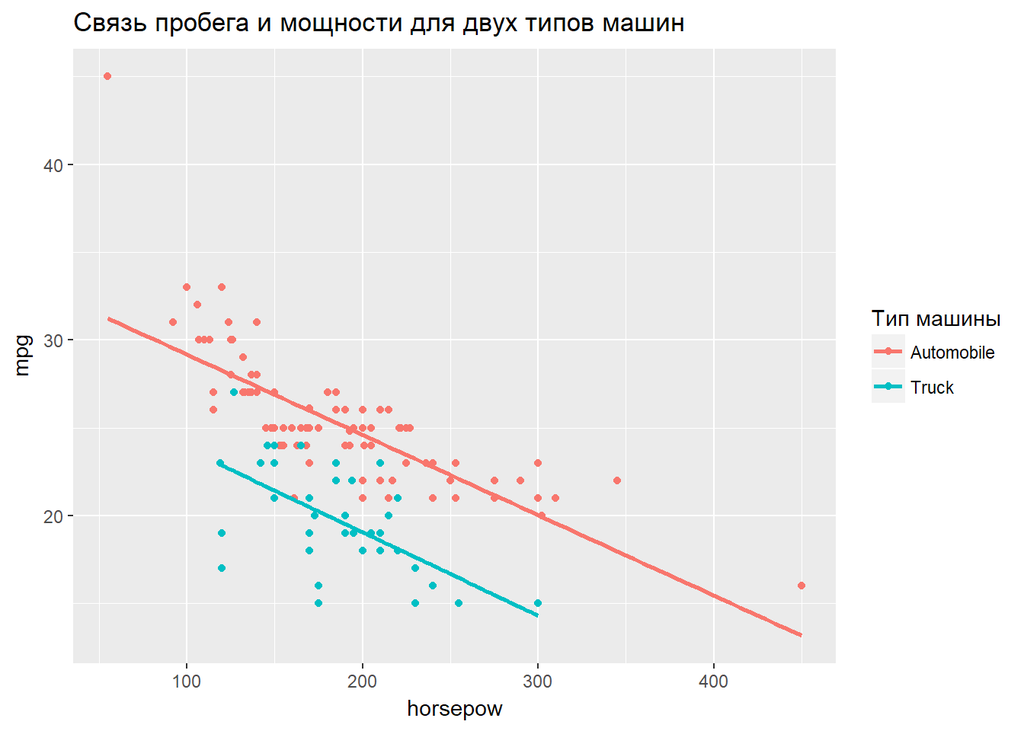

```r
ggplot(cars2, aes(horsepow, mpg, colour = type)) +
  geom_point() +
  geom_smooth(method = lm, se = F) +
  labs(title = "Связь пробега и мощности для двух типов машин",
       colour = "Тип машины")
```

При расщеплении данных по типу машины видно, что при той же мощности двигателя пробег на галлоне топлива для грузовиков значительно меньше. Линия регрессии для грузовиков смещена вниз по сравнению с линией для легковых машин.

Для того, чтобы учесть в модели различие в типах машин, можно включить в модель **фиктивную переменную** (*dummy variable*), принимающую значение 0 или 1 в зависимости от типа машины. Значение 0 соответствует базовой категории (выбирается произвольно, в нашем случае примем, что базовая категория (*reference category*) - легковой автомобиль, тип Automobile), а значение 1 - категории, которая сравнивается с базовой (Truck).

**Замечание:** здесь эта операция сделана в иллюстративных целях. R может автоматически преобразовывать категориальные предикторы в наборы фиктивных переменных (см. далее).

```r
carsdummy <- cars2 %>%
  mutate(truck = ifelse(type == "Truck", 1, 0))

m_pow_dummy <- lm(mpg ~ horsepow + truck, data = carsdummy)

summary(m_pow_dummy)
```

```
##
## Call:
## lm(formula = mpg ~ horsepow + truck, data = carsdummy)
##
## Residuals:
##    Min     1Q Median     3Q    Max
## -5.752 -1.466 -0.081  1.378 13.740
##
## Coefficients:
##             Estimate Std. Error t value Pr(>|t|)
## (Intercept)  33.7879     0.6646    50.8   <2e-16 ***
## horsepow     -0.0460     0.0034   -13.5   <2e-16 ***
## truck        -5.5213     0.4368   -12.6   <2e-16 ***
## ---
## Signif. codes:  0 '***' 0.001 '**' 0.01 '*' 0.05 '.' 0.1 ' ' 1
##
## Residual standard error: 2.37 on 149 degrees of freedom
## Multiple R-squared:  0.701,  Adjusted R-squared:  0.697
## F-statistic:  174 on 2 and 149 DF,  p-value: <2e-16
```

Получена модель:

$$\widehat{mpg} = 33.8 - 0.046 \cdot horsepow - 5.5 \cdot truck$$

Таким образом, для грузовиков (`truck = 1`), значение переменной `mpg` на 5.5 миль/галлон меньше, чем для автомобилей (`truck = 0`). Т.е. для грузовиков линия регрессии смещается вниз на 5.5. Коэффициент для фиктивной переменной в этой модели показывает отличие категории грузовиков от базовой: свободный член $b_0$ для автомобилей = 33.8, для грузовиков - 28.3.

R может автоматически добавлять фиктивные переменные, если в модель включены категориальные переменные (факторы). При этом базовой категории будет соответствовать первый уровень фактора.

```r
cars2f <- cars2 %>%
  mutate(type = factor(type, levels = c('Automobile', 'Truck')))


m_pow_factor <- lm(mpg ~ horsepow + type, data = cars2f)

summary(m_pow_factor)
```

```
##
## Call:
## lm(formula = mpg ~ horsepow + type, data = cars2f)
##
## Residuals:
##    Min     1Q Median     3Q    Max
## -5.752 -1.466 -0.081  1.378 13.740
##
## Coefficients:
##             Estimate Std. Error t value Pr(>|t|)
## (Intercept)  33.7879     0.6646    50.8   <2e-16 ***
## horsepow     -0.0460     0.0034   -13.5   <2e-16 ***
## typeTruck    -5.5213     0.4368   -12.6   <2e-16 ***
## ---
## Signif. codes:  0 '***' 0.001 '**' 0.01 '*' 0.05 '.' 0.1 ' ' 1
##
## Residual standard error: 2.37 on 149 degrees of freedom
## Multiple R-squared:  0.701,  Adjusted R-squared:  0.697
## F-statistic:  174 on 2 and 149 DF,  p-value: <2e-16
```

Результаты идентичны модели, в которой фиктивная переменная добавлена вручную.

### Модель с учетом взаимодействия предикторов

Рассмотрим связь пробега на 1 галлоне топлива с другой переменной - `curb_wgt`.

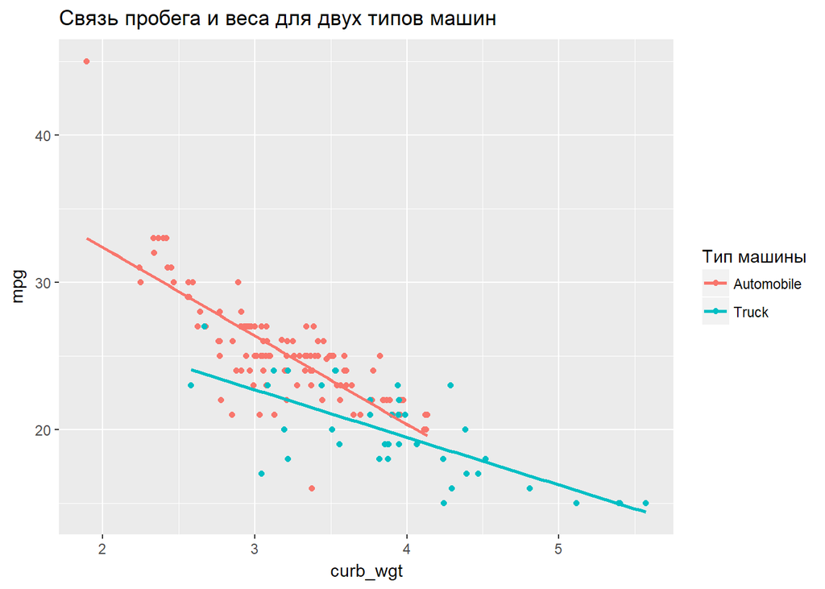

```r
ggplot(data = cars2, aes (curb_wgt, mpg, colour = type)) +
  geom_point() +
  geom_smooth(method = lm, se = F) +
  labs(title = "Связь пробега и веса для двух типов машин",
     colour = "Тип машины")
```

На этом графике видно, что регрессионные прямые для подгрупп не просто смещены, у них разный наклон. Таким образом, оба коэффициента - свободный член и угловой коэффициент для подгрупп отличаются. Отличия углового коэффициента для подгрупп обусловлено **взаимодействием** (*interaction*) факторов: угловой коэффициент для веса зависит от значения другой переменной (тип машины).

При моделировании взаимодействие включается в уравнение как произведение двух взаимодействующих переменных. Однако в R есть специальный синтаксис для взаимодействия:`var1:var2`.

```r
m_wgt_interact <- lm(mpg ~ curb_wgt + type + curb_wgt:type, data = cars2f)

summary(m_wgt_interact)
```

```
##
## Call:
## lm(formula = mpg ~ curb_wgt + type + curb_wgt:type, data = cars2f)
##
## Residuals:
##    Min     1Q Median     3Q    Max
## -8.129 -1.132  0.183  1.178 11.984
##
## Coefficients:
##                    Estimate Std. Error t value Pr(>|t|)
## (Intercept)          44.395      1.437   30.90  < 2e-16 ***
## curb_wgt             -6.005      0.447  -13.42  < 2e-16 ***
## typeTruck           -11.970      2.527   -4.74  5.0e-06 ***
## curb_wgt:typeTruck    2.771      0.686    4.04  8.6e-05 ***
## ---
## Signif. codes:  0 '***' 0.001 '**' 0.01 '*' 0.05 '.' 0.1 ' ' 1
##
## Residual standard error: 2.26 on 148 degrees of freedom
## Multiple R-squared:  0.731,  Adjusted R-squared:  0.725
## F-statistic:  134 on 3 and 148 DF,  p-value: <2e-16
```

Получено уравнение модели:

$$\widehat{mpg} = 44.4 - 6.0 curb\_wgt - 12 (type=Truck) + 2.8 curb\_wgt (type=Truck)$$

Сравним модели для двух подгрупп.

Для легковых автомобилей (`type = Automobile`):

$$\widehat{mpg} = 44.4 - 6 curb\_wgt$$

Для грузовиков `type = Truck`:

$$\widehat{mpg} = (44.4 - 12.0) -6.0 curb\_wgt + 2.8 curb\_wgt$$

или:

$$\widehat{mpg} = 32.4 - 3.2 curb\_wgt$$

Таким образом, получилось, что и свободный член, и угловой коэффициент для подгрупп отличаются.

Заметим, что в R можно получить модель, включающую как предикторы по отдельности, так и во взаимодействии, используя синтаксис формулы: `var1 * var2`.

```r
lm(mpg ~ curb_wgt * type, data = cars2f) %>%
  summary()
```

```
##
## Call:
## lm(formula = mpg ~ curb_wgt * type, data = cars2f)
##
## Residuals:
##    Min     1Q Median     3Q    Max
## -8.129 -1.132  0.183  1.178 11.984
##
## Coefficients:
##                    Estimate Std. Error t value Pr(>|t|)
## (Intercept)          44.395      1.437   30.90  < 2e-16 ***
## curb_wgt             -6.005      0.447  -13.42  < 2e-16 ***
## typeTruck           -11.970      2.527   -4.74  5.0e-06 ***
## curb_wgt:typeTruck    2.771      0.686    4.04  8.6e-05 ***
## ---
## Signif. codes:  0 '***' 0.001 '**' 0.01 '*' 0.05 '.' 0.1 ' ' 1
##
## Residual standard error: 2.26 on 148 degrees of freedom
## Multiple R-squared:  0.731,  Adjusted R-squared:  0.725
## F-statistic:  134 on 3 and 148 DF,  p-value: <2e-16
```

Результат идентичен предыдущей модели.

### Категориальные предикторы с более чем двумя категориями

Если в модель включен фактор с более чем двумя уровнями, то R автоматически добавит в уравнение фиктивные переменные для каждой категории, кроме базовой. Таким образом, можно будет оценить, как каждая из категорий отличается от базовой.

Рассмотрим пример фактора с 3 уровнями - страна производителя машины. В качестве базовой категории выберем Японию (предполагая, что японские машины - самые экономичные).

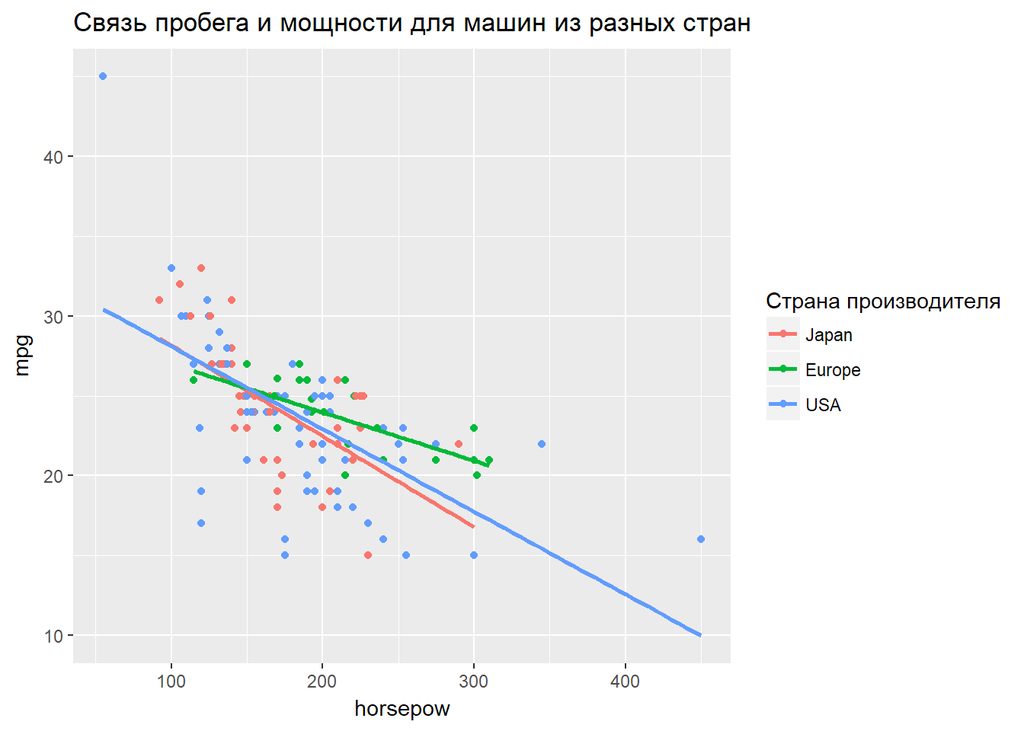

```r
cars2f <- cars2f %>%
  mutate(country = factor(country, levels=c('Japan', 'Europe', 'USA')))

ggplot(cars2f, aes(horsepow, mpg, colour = country)) +
  geom_point() +
  geom_smooth(method = lm, se = F) +
  labs(title = "Связь пробега и мощности для машин из разных стран",
     colour = "Страна производителя")
```

Заметно небольшое отличие между эффективностью японских и американских машин, при этом наклон прямых отличается слабо. Гипотеза об большей экономичности японских машин не подтвердилась. Для европейских машин отличие в наклоне более выражено, т.е. у этих машин не только больше эффективность, но и при увеличении мощности эффективность падает не так сильно, как у двух других групп.

Вначале построим модель без учета взаимодействия факторов.

```r
m_country <- lm(mpg ~ horsepow + country, data = cars2f)

summary(m_country)
```

```
##
## Call:
## lm(formula = mpg ~ horsepow + country, data = cars2f)
##
## Residuals:
##    Min     1Q Median     3Q    Max
## -9.817 -1.993  0.552  2.111 15.079
##
## Coefficients:
##               Estimate Std. Error t value Pr(>|t|)
## (Intercept)   32.24760    1.00764   32.00   <2e-16 ***
## horsepow      -0.04775    0.00491   -9.73   <2e-16 ***
## countryEurope  1.23676    0.79300    1.56     0.12
## countryUSA     0.29939    0.64896    0.46     0.65
## ---
## Signif. codes:  0 '***' 0.001 '**' 0.01 '*' 0.05 '.' 0.1 ' ' 1
##
## Residual standard error: 3.39 on 148 degrees of freedom
## Multiple R-squared:  0.39,   Adjusted R-squared:  0.378
## F-statistic: 31.6 on 3 and 148 DF,  p-value: 7.61e-16
```

Из коэффициентов модели следует, что для европейских машин пробег на галлоне, в среднем, на 1.2 мили больше, чем для японских, а для американских машин - в среднем, на 0.3 мили больше, чем для японских.

Поскольку мы видели, что наклон регрессионных прямых для подгрупп отличается, необходимо построить модель со взаимодействием факторов.

```r
m_country_interact <- lm(mpg ~ horsepow * country, data = cars2f)

summary(m_country_interact)
```

```
##
## Call:
## lm(formula = mpg ~ horsepow * country, data = cars2f)
##
## Residuals:
##     Min      1Q  Median      3Q     Max
## -10.075  -1.529   0.089   2.067  14.559
##
## Coefficients:
##                        Estimate Std. Error t value Pr(>|t|)
## (Intercept)            33.85946    2.03914   16.60  < 2e-16 ***
## horsepow               -0.05690    0.01120   -5.08  1.1e-06 ***
## countryEurope          -3.82840    2.91564   -1.31     0.19
## countryUSA             -0.56980    2.38740   -0.24     0.81
## horsepow:countryEurope  0.02659    0.01508    1.76     0.08 .
## horsepow:countryUSA     0.00511    0.01291    0.40     0.69
## ---
## Signif. codes:  0 '***' 0.001 '**' 0.01 '*' 0.05 '.' 0.1 ' ' 1
##
## Residual standard error: 3.37 on 146 degrees of freedom
## Multiple R-squared:  0.407,  Adjusted R-squared:  0.387
## F-statistic:   20 on 5 and 146 DF,  p-value: 3.55e-15
```

Включение всех взаимодействий привело к тому, что часть коэффициентов получились незначимыми. При увеличении количества переменных в модели каждый из них оценивается по меньшему количеству независимых данных (уменьшается число степеней свободы), поэтому растет стандартная ошибка оценки коэффициента.

Мы видели, что наклон линий отличается существенно только для европейских машин, поэтому попробуем построить модель со взаимодействием только для этой категории машин.

```r
# Подготовка данных: добавляем новый фактор - европейская машина, или нет.

cars2f <- cars2f %>%
  mutate(europe = fct_recode(country,
                             No = "Japan",
                             No = "USA",
                             Yes = "Europe"))


m_europe_interact <- lm(mpg ~ horsepow + horsepow:europe,
                                data = cars2f)

summary(m_europe_interact)
```

```
##
## Call:
## lm(formula = mpg ~ horsepow + horsepow:europe, data = cars2f)
##
## Residuals:
##    Min     1Q Median     3Q    Max
## -9.754 -1.781  0.271  2.201 15.033
##
## Coefficients:
##                    Estimate Std. Error t value Pr(>|t|)
## (Intercept)        32.68584    0.93768   34.86   <2e-16 ***
## horsepow           -0.04943    0.00500   -9.88   <2e-16 ***
## horsepow:europeYes  0.00678    0.00329    2.06    0.041 *
## ---
## Signif. codes:  0 '***' 0.001 '**' 0.01 '*' 0.05 '.' 0.1 ' ' 1
##
## Residual standard error: 3.37 on 149 degrees of freedom
## Multiple R-squared:  0.397,  Adjusted R-squared:  0.389
## F-statistic:   49 on 2 and 149 DF,  p-value: <2e-16
```

Взаимодействие региона и мощности значимо.

Уравнение модели:

Для американских и японских машин (europe = No):

$$\widehat{mpg} = 32.7 - 0.05 horsepow$$

Сравним прогнозируемую эффективность машин с одинаковой мощностью - 250 л.с. из разных стран:

```r
# Новые данные
new_cars <- data.frame(horsepow = c(250, 250),
                       europe = factor(c("No", "Yes"), levels = c("No", "Yes")))

# Прогноз
pred_mpg <- predict(m_europe_interact, new_cars,
                    interval = "prediction",
                    level = 0.9) %>%
  as.data.frame() %>%
  bind_cols(new_cars, .)

pred_mpg
```

```
##   horsepow europe  fit  lwr  upr
## 1      250     No 20.3 14.7 26.0
## 2      250    Yes 22.0 16.3 27.7
```